# Amsterdam Airbnb Price Prediction

Technical Report

Nawal Zehra Hasan

2022-02-10

# EXECUTIVE SUMMARY

The idea of the following report is to provide statistical models capable of predicting the rental prices in Amsterdam of apartments accommodating between 2 to 6 persons. With a project like this Airbnbs rentals can estimate at what price should they rent out their apartments and what the profit margins will be at that given price. Using 5 machine learning algorithms; OLS Linear regression, LASSO, and Random Forest, CART & GBM I was able to perform this analysis.

## THE DATASET

To accomplish the given task, I have used the Airbnb data for Amsterdam for the date 7th September 2021 that is available on Inside Airbnb website. The dataset has a single table that includes 16116 observations.

The target variable given is price per night in USD. The predictors consist of several variables related to property reviews, neighborhood, amenities offered etc. The data set had several variables that would reflect the quality of an Airbnb rental. This shows that data collection was thorough and detailed.

## DATA MUNGING

The dataset required a lot of cleaning to make it suitable for use specifically for my analysis. This method of tweaking the data by filtering variables, renaming variables and dealing with missing values etc is the first and most important part of the analytical process. Our results depend on it so this took me quite some time to produce accurate results.

I deleted some unused columns and renamed some columns for easier use in the modeling process. I changed the price variables to exclude the dollar symbol from the price making it into a numerical column. Then I dropped all observations that had price missing. For many missing values in a column such as ‘review_scores_value’ & ‘review_scores_communication’, I dropped these columns altogether. I also checked for duplicates and found none. I filtered the data on property types specifically targeting apartments including lofts, rental units and serviced apartments as a requirement by the study and changed it to a factor variables.

After this we were left with 10082 observations. These property types were renamed to make it easier for use. The amenities column consisted of a vector of different amenities (like “air conditioning,”stove”, “beach”) which needed to be split apart into individual binary columns. This resulted in more than 400 new columns being added. Using a function which searches for a particular key word (like “wifi” or “parking”) through all column names and aggregates them into one general binary column. I chose a few amenities and dropped the rest. Lastly, I created dummy variables for all the categorical variables in our data such as amenities and availability.

## EXPLORATORY DATA ANALYSIS

After the data was cleaned, I conducted Exploratory Data Analysis to try to understand the characteristics of our data. This meant checking their descriptive statistics, their distributions and their relationship with price.

### LABEL ENGINEERING

Descriptive statistics of target variable

| Variable | Mean | 5th Percentile | Median | 95th Percentile | Std | Min | Max | N |
| --- | --- | --- | --- | --- | --- | --- | --- | --- |
| price_day | 161.68 | 77 | 139 | 300 | 165.62 | 4 | 8000 | 10082 |

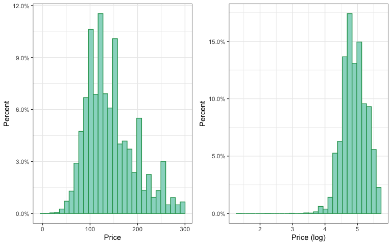

### FEATURE ENGINEERING

After deciding the functional form of the target variable I inspected the predictor variables and their relationship with the target variable.

First, I inspected the I wanted to check the accommodation capacity for the data we had. As we were restricted to choose Airbnbs which accommodated between 2 to 6 guests we can from the figure below that most Airbnbs in our sample had a capacity to accommodate 2 persons, followed by 4 persons. One of the most important numeric variables to determine price is the number of guests the apartment can accommodate. The chart next to that shows prices conditional on guests accommodated. We can see an almost linear pattern using a non-parametric regression showing prices to increase as accommodation capacity increases. This is also confirmed by the box plots showing accommodation capacity by price. The box plot also shows that there is no significant change in prices between apartments that are instantly avaiable compared to those that afre not. I have still taken quadratic of the accommodation as explained in the models later.

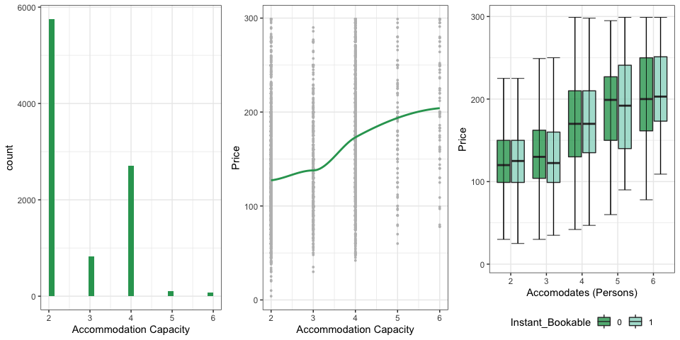

The box plots below reveal that serviced apartments and lofts cost more on average compared to apartments and rental units. In my sample, there were very few observations in the apartments category as compared to the rest, so I added entire rental units to be able to make better conclusions. However, the average price of serviced apartments tends to vary significantly as the capacity to accommodate people rises. This is different for entire rental units, as the accommodation capacity increases it results in a corresponding higher price.

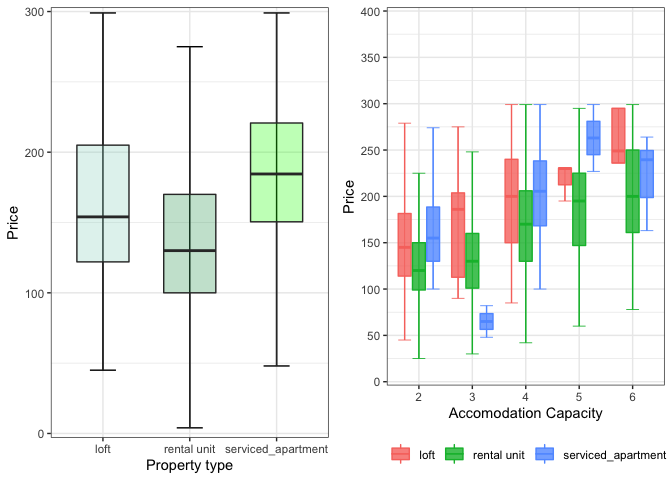

We looked at the distribution of beds, as beds is the same as accommodation capacity and decided to take logs to as the pattern of association with price was non linear.

I looked at the distribution of other variables as well, to check whether any required transformation and what functional form works best for each. I pooled some of the observations in columns into groups. These included ‘n_number_of reviews’, ‘n_number_of_bathrooms, ’n_minimum_nights’.For example if the accommodation had 0,1,2 or 5 bathrooms. Then I imputed the missing values depending on on the type of object it represents. For example, we filled ‘1’ or ‘0’ in missing values in ‘n_number_of_nights’ column.

I also examined the interactions between dummy variables and the factor variable property type. I tested many interpretations to see what kind of relationship the two variables had with one other. A few of those interactions are shown below. In these interactions, wherever I observed great difference in categories I added these to the models later as interactions. I used data driven modeling that have its advantages but they are unstable as opposed to theory driven.

By the end of the label and feature engineering process the data set contained 9477 observations in total for apartments that can accommodate 2-6 guests with 31 variables including dummy variables, factors, numerical and flagged variables.

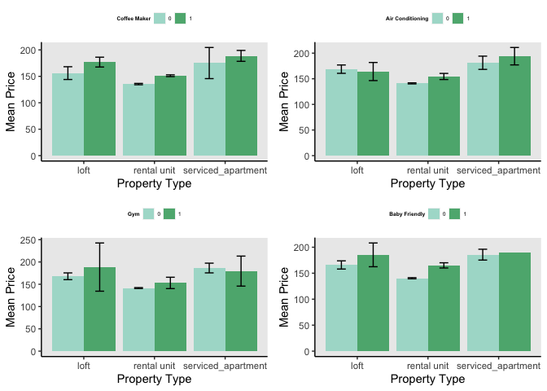

## MACHINE LEARNING MODELING

For predicting price per night I used five different types of models:

- OLS
- LASSO
- Random forest.
- CART
- GBM

### CONSTRUCTING THE REGRESSION MODELS

First, I split the data into two parts: a training set and a holdout set.Out of which I used 30% of the data at random as holdout set. The rest of the workout set was used for cross validation with 5 folds of training and test sets. With these I estimated many models with different sets of variables or tuning parameters according to the model in use. Lastly, I calculated the RMSE on the test set and holdout set to determine which of the models is the performing best.

**Versions of the Airbnb Apartment Price Prediction Models**

| Model | Predictor Variables |
| --- | --- |
| M1 | = Number of guests accommodated, number of bedrooms, average review scores, guests accommodated (squared term), property type, minimum nights, number of reviews, number of bathrooms, log number of bed… |
| M2 | = M1 + all amenities |
| M3 | = M2 + amenities interactions |

### OLS PREDICTIVE MODELS

**Comparisng Model Fit measures**

| Model | N predictors | R-squared | BIC | Training RMSE | Test RMSE |
| --- | --- | --- | --- | --- | --- |
| Model 1 | 10 | 0.21 | 69471 | 45.15 | 45.07 |
| Model 2 | 22 | 0.23 | 69387 | 44.64 | 44.43 |
| Model 3 | 35 | 0.23 | 69490 | 44.72 | 44.40 |

### LASSO

By assigning a substantial set of predictors, we can run Lasso that will return the coefficients relevant and assign the rest a value of zero. Its interesting to note that we received an RMSE of 44.61 with LASSO which is slightly lower than that of model 2 which we chose using OLS regression.

### RANDOM FOREST

Random Forest is a regression method based on trees and it seeks inspiration from OLS modeling. It also used the k-fold cross validation approach and gives prediction according to the holdout set picked out during OLS modeling. However, this modeling method does not use any interaction terms so it leaves us with as many predictors as there are coefficients. I tested 3 models through Random Forest. The first one includes the numeric variables. The second included numeric and factor variables. The third model included all those and the dummy amenities.

**Versions of the Airbnb Apartment Price Prediction Models for Random Forest**

| Model | Predictor Variables |
| --- | --- |
| M1 | = guests accommodated, number of beds, number of bedrooms, average review scores, |
| M2 | = M1 + f_property_type, f_minimum_nights,f_number_of_reviews, f_bathroom, |
| M3 | = M3 + all amenities columns |

The tuning parameters are further used to fit the model. Model 1 gives us an average Test RMSE of 45.44 while Model 2 gives us an average Test RMSE of 44.75. However, model 3 gave the lowest average RMSE at 44.63 doing the best job at predicting prices.The performance the RMSE over the 5 folds by each model is shown in the table below:

**RMSE fold results for all models**

|  | Model 1 | Model 2 | Model 3 |
| --- | --- | --- | --- |
| Fold 1 | 44.791 | 43.7860 | 43.6590 |
| Fold 2 | 44.546 | 44.0180 | 43.8280 |
| Fold 3 | 46.014 | 45.5430 | 45.8990 |
| Fold 4 | 45.985 | 45.0820 | 44.6630 |
| Fold 5 | 45.869 | 45.3440 | 45.1270 |
| Average | 45.441 | 44.7546 | 44.6352 |

### VARIABLE IMPORTANCE

Using a diagnostic tool as Variable Importance charts we can determine which of the variables contributed most to the RMSE. I used model 3 as it emerged as the best model for rain forest. Using that I created 2 variable importance plots. The first one shows the top 10 most important variables with respect to their contribution. The second one shows the grouped variable importance. It can be concluded that the number of people accommodated by the Airbnb and the number of bedrooms are the most important characteristic for determine the price and also contributes to 70% of the RMSE reduction.

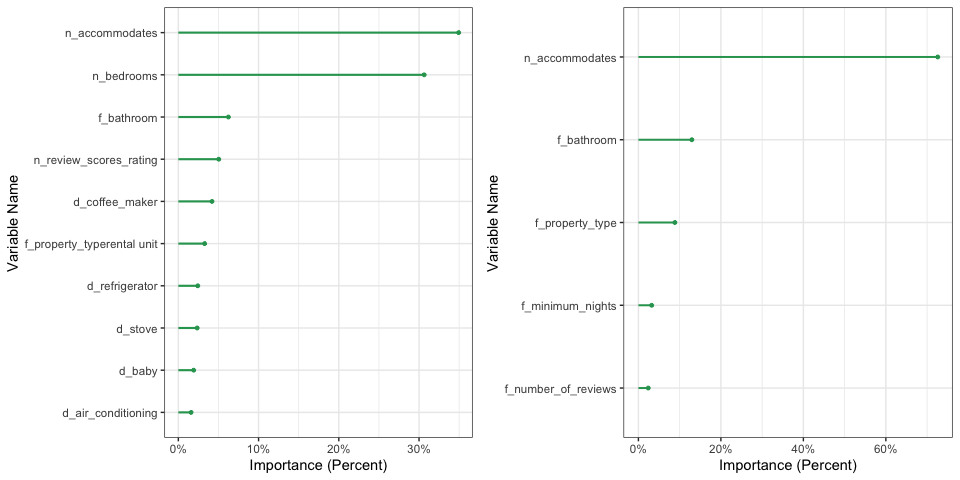

## PARTIAL DEPENDENCIES PLOT

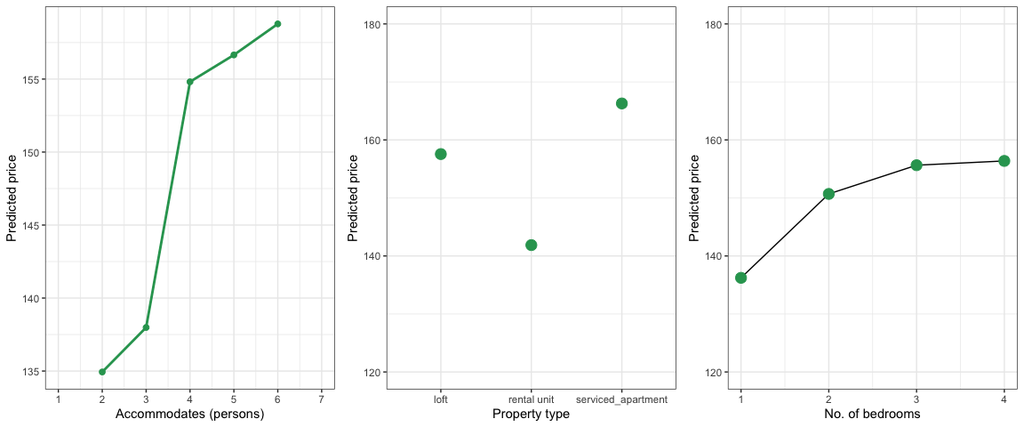

### MODEL SELECTION

My task was to find the prediction prices for rental apartments with 2-6 accommodation capacity. I used my limited understanding of machine learning methods to design various models and ran them through various Machine Learning algorithms like OLS, Lasso, and Random Forest, CART & GBM.

After executing several models, I chose the best ones predicting prices using each method. The table below shows their cross-validated RMSE-s and the RMSE-s calculated using the holdout set. Compared with the results of the case study predicting Airbnb prices for London the ranking of models different.LASSO had the best performance followed by random forest with a CV-RMSE OF 44.63. This means that in our live data, there is a possibility of making an error of 44.63$ on live data in the Airbnb of Amsterdam assuming that the external validity is high.

Model performance comparison

|  | CV RMSE | Holdout RMSE |
| --- | --- | --- |
| OLS Model 2 | 44.64 | 44.82 |
| LASSO (model with interactions) | 44.62 | 44.85 |
| Random forest(with amenities) | 44.63 | 45.22 |
| GBM | 44.90 | 45.66 |
| CART | 45.08 | 45.63 |

## SUMMARY

This gave me an understanding of the different approaches and choices one can make for predictions. This showed that not one single model is better but rather the decision depends on the situation at hand, requirement of the study and the understanding of the analyst.

Note:

link to github repository: https://github.com/nawalhasan/DA3